# Project 3 - Sequential Classification

*Noah Trilling*

```python
import glob
from scipy.io import loadmat
import matplotlib.pyplot as plt
import seaborn as sns
import pandas as pd
import numpy as np
from sklearn.model_selection import train_test_split
from tensorflow.keras.models import Sequential
from tensorflow.keras.layers import Dense, Input, Conv1D, MaxPooling1D, Flatten, Dropout, SimpleRNN, Bidirectional, BatchNormalization, LSTM, ReLU
from tensorflow.keras.utils import to_categorical
from sklearn.preprocessing import LabelEncoder
from sklearn.metrics import roc_auc_score, f1_score, confusion_matrix, ConfusionMatrixDisplay
import keras_tuner as kt
from tensorflow.keras.callbacks import EarlyStopping
from tensorflow.keras.optimizers import AdamW
from sklearn.utils.class_weight import compute_class_weight
from sklearn.utils import resample
from tensorflow.keras.regularizers import l2

the_answer = 42
```

## Download and Explore the Data

Use Scipy’s loadmat() function to load the files, i.e. from scipy.io import loadmat. Start by loading some the recordings and plotting them.

```python
mat_files = glob.glob('./training2017/*.mat')
x = [loadmat(f) for f in mat_files]
```

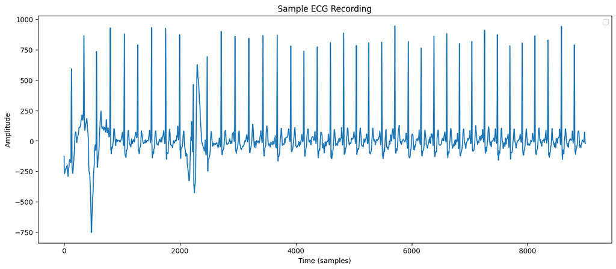

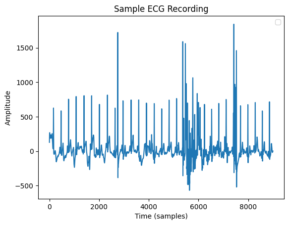

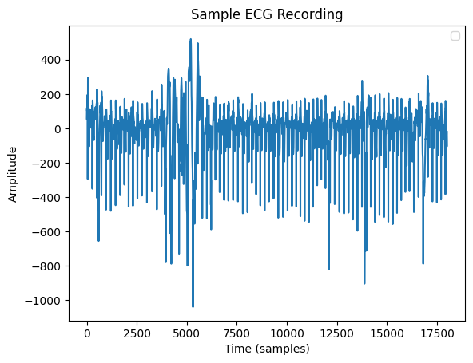

```python
plt.figure(figsize=(15, 6))
for i in range(3):
    signal = x[i]['val'].squeeze()
    sns.lineplot(x=range(len(signal)), y=signal)
    plt.xlabel('Time (samples)')
    plt.ylabel('Amplitude')
    plt.title('Sample ECG Recording')
    plt.legend()
    plt.show()
```

```python
print(f"Total number of recordings: {len(x)}")
```

```
Total number of recordings: 8528
```

Generate a table and count plot for the number of recordings in each category.

```
category
N    5050
O    2456
A     738
~     284
Name: count, dtype: int64
```

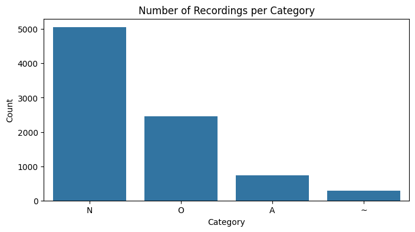

```python
y_df = pd.read_csv('./training2017/REFERENCE.csv', names=['recording', 'category'])
category_counts = y_df['category'].value_counts()
display(category_counts)

plt.figure(figsize=(8, 4))
sns.countplot(x='category', data=y_df, order=category_counts.index)
plt.title('Number of Recordings per Category')
plt.xlabel('Category')
plt.ylabel('Count')
plt.show()
```

Look at the distribution of lengths of the recordings – are they the same?

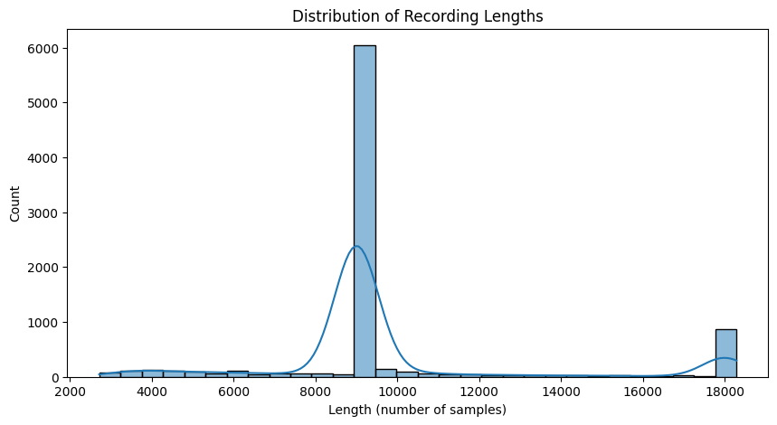

```python
lengths = [d['val'].shape[1] for d in x]

plt.figure(figsize=(10, 5))
sns.histplot(lengths, bins=30, kde=True)
plt.title('Distribution of Recording Lengths')
plt.xlabel('Length (number of samples)')
plt.ylabel('Count')
plt.show()
```

## Build several machine learning models to classify this data

### Data Preprocessing

The ECG sequences are not the same length. There are model architectures available for dealing with sequences of arbitrary length, but for simplicity we will preprocess these sequences so that they have the same length. There are many possible ways to do this, for example:

Pad the end of each sequence with zeros to make it the length of the longest overall sequence;

Take the first t data points for each sequence, where t is the length of the shortest sequence;

Sample a window of each sequence of length t, where t is less than or equal to the length of the shortest sequence;

Choose and implement a strategy for making the sequences the same length.

```python
median_len = int(np.median(lengths))

x = np.array([
    np.pad(d['val'].squeeze()[:median_len], (0, max(0, median_len - d['val'].squeeze().shape[0])), mode='constant')
    for d in x
])

input_length = x.shape[1]
print(f"Input length after padding: {input_length}")
```

```
Input length after padding: 9000
```

Split the data into training, validation, and testing sets.

```python
y = y_df['category'].values

categories = sorted(np.unique(y))
category_to_index = {cat: idx for idx, cat in enumerate(categories)}
index_to_category = {idx: cat for cat, idx in category_to_index.items()}

x_mean = x.mean(axis=1, keepdims=True)
x_std = x.std(axis=1, keepdims=True)
x = (x - x_mean) / (x_std + 1e-8)

x_train, x_temp, y_train, y_temp = train_test_split(
    x, y, test_size=0.2, random_state=the_answer, stratify=y
)

x_val, x_test, y_val, y_test = train_test_split(
    x_temp, y_temp, test_size=0.5, random_state=the_answer, stratify=y_temp
)

y_train = np.array([category_to_index[label] for label in y_train])
y_val = np.array([category_to_index[label] for label in y_val])
y_test = np.array([category_to_index[label] for label in y_test])

num_classes = len(np.unique(y_train))
```

### Dense Neural Network

Use Keras to build a dense NN to classify these sequences. Begin with a single hidden layer. Use accuracy as your metric and Adam as your optimizer.

```python
model = Sequential([
    Input(shape=(input_length,)),
    Dense(16, activation='relu'),
    Dense(num_classes, activation='softmax')
])

model.compile(optimizer='adam', loss='sparse_categorical_crossentropy', metrics=['accuracy'])

history = model.fit(
    x_train, y_train,
    validation_data=(x_val, y_val),
    epochs=10,
    batch_size=32
)
```

```
WARNING:tensorflow:6 out of the last 73 calls to <function TensorFlowTrainer._make_function.<locals>.multi_step_on_iterator at 0x0000017A911411C0> triggered tf.function retracing. Tracing is expensive and the excessive number of tracings could be due to (1) creating @tf.function repeatedly in a loop…
214/214 ━━━━━━━━━━━━━━━━━━━━ 2s 3ms/step - accuracy: 0.4307 - loss: 1.8357 - val_accuracy: 0.4783 - val_loss: 1.4591
214/214 ━━━━━━━━━━━━━━━━━━━━ 1s 2ms/step - accuracy: 0.6558 - loss: 0.8906 - val_accuracy: 0.4842 - val_loss: 1.4174
214/214 ━━━━━━━━━━━━━━━━━━━━ 1s 2ms/step - accuracy: 0.7356 - loss: 0.6735 - val_accuracy: 0.4795 - val_loss: 1.4506
214/214 ━━━━━━━━━━━━━━━━━━━━ 1s 2ms/step - accuracy: 0.8000 - loss: 0.5234 - val_accuracy: 0.5100 - val_loss: 1.5845
214/214 ━━━━━━━━━━━━━━━━━━━━ 1s 2ms/step - accuracy: 0.8475 - loss: 0.4309 - val_accuracy: 0.4947 - val_loss: 1.7280
214/214 ━━━━━━━━━━━━━━━━━━━━ 1s 2ms/step - accuracy: 0.8770 - loss: 0.3561 - val_accuracy: 0.5064 - val_loss: 1.9278
214/214 ━━━━━━━━━━━━━━━━━━━━ 1s 2ms/step - accuracy: 0.9008 - loss: 0.2894 - val_accuracy: 0.4830 - val_loss: 2.0899
214/214 ━━━━━━━━━━━━━━━━━━━━ 1s 2ms/step - accuracy: 0.9176 - loss: 0.2396 - val_accuracy: 0.4748 - val_loss: 2.3607
214/214 ━━━━━━━━━━━━━━━━━━━━ 1s 2ms/step - accuracy: 0.9339 - loss: 0.2033 - val_accuracy: 0.4830 - val_loss: 2.4689
214/214 ━━━━━━━━━━━━━━━━━━━━ 1s 2ms/step - accuracy: 0.9437 - loss: 0.1671 - val_accuracy: 0.4889 - val_loss: 2.6941
```

#### DNN Metrics

All the metrics should be generated after predicting on the testing set.

```python
y_pred_probs = model.predict(x_test)
y_pred = np.argmax(y_pred_probs, axis=1)
```

```
27/27 ━━━━━━━━━━━━━━━━━━━━ 0s 3ms/step
```

Compute the F1 score for each class.

```python
f1_per_class = f1_score(y_test, y_pred, average=None)
for idx, score in enumerate(f1_per_class):
    print(f"F1 score for class {index_to_category[idx]}: {score}")
```

```
F1 score for class A: 0.06060606060606061
F1 score for class N: 0.6088631984585742
F1 score for class O: 0.2929936305732484
F1 score for class ~: 0.06153846153846154
```

Compute and report the overall F1 score as the average of the computed F1 scores.

```python
overall_f1 = np.mean(f1_per_class)
print(f"Overall F1 score (average across classes): {overall_f1:.4f}")
```

```
Overall F1 score (average across classes): 0.2560
```

Report the AUC score.

```python
auc_score = roc_auc_score(y_test, y_pred_probs, average='macro', multi_class='ovr')
print(f"AUC score (macro, one-vs-rest): {auc_score:.4f}")
```

```
AUC score (macro, one-vs-rest): 0.5323
```

Also, construct confusion matrices.

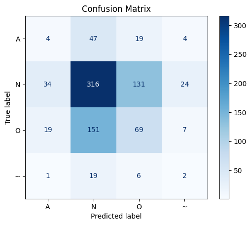

```python
cm = confusion_matrix(y_test, y_pred)
disp = ConfusionMatrixDisplay(confusion_matrix=cm, display_labels=[index_to_category[idx] for idx in range(num_classes)])
plt.figure(figsize=(6, 6))
disp.plot(cmap='Blues', values_format='d')
plt.title('Confusion Matrix')
plt.show()
```

### Convolutional Neural Network

Use Keras to build a second deep learning model, using convolutional neural networks, to classify these sequences. Use accuracy as your metric and Adam as your optimizer.

```python
cnn_model = Sequential([
    Input(shape=(input_length, 1)),
    Conv1D(32, kernel_size=7, activation='relu'),
    Flatten(),
    Dense(32, activation='relu'),
    Dense(num_classes, activation='softmax')
])

cnn_model.compile(optimizer='adam', loss='sparse_categorical_crossentropy', metrics=['accuracy'])

cnn_history = cnn_model.fit(
    x_train, y_train,
    validation_data=(x_val, y_val),
    epochs=10,
    batch_size=32
)
```

```
214/214 ━━━━━━━━━━━━━━━━━━━━ 30s 134ms/step - accuracy: 0.4946 - loss: 2.2840 - val_accuracy: 0.5498 - val_loss: 1.0527
214/214 ━━━━━━━━━━━━━━━━━━━━ 29s 136ms/step - accuracy: 0.6265 - loss: 0.8794 - val_accuracy: 0.5639 - val_loss: 1.0667
214/214 ━━━━━━━━━━━━━━━━━━━━ 30s 140ms/step - accuracy: 0.6847 - loss: 0.7725 - val_accuracy: 0.5498 - val_loss: 1.1324
214/214 ━━━━━━━━━━━━━━━━━━━━ 30s 139ms/step - accuracy: 0.7450 - loss: 0.6498 - val_accuracy: 0.5299 - val_loss: 1.2237
214/214 ━━━━━━━━━━━━━━━━━━━━ 28s 132ms/step - accuracy: 0.7597 - loss: 0.5771 - val_accuracy: 0.4830 - val_loss: 1.3847
214/214 ━━━━━━━━━━━━━━━━━━━━ 27s 127ms/step - accuracy: 0.8224 - loss: 0.4712 - val_accuracy: 0.4701 - val_loss: 1.5450
214/214 ━━━━━━━━━━━━━━━━━━━━ 28s 131ms/step - accuracy: 0.8635 - loss: 0.3834 - val_accuracy: 0.4748 - val_loss: 1.9082
214/214 ━━━━━━━━━━━━━━━━━━━━ 30s 139ms/step - accuracy: 0.8992 - loss: 0.2937 - val_accuracy: 0.4490 - val_loss: 2.1805
214/214 ━━━━━━━━━━━━━━━━━━━━ 30s 141ms/step - accuracy: 0.9260 - loss: 0.2326 - val_accuracy: 0.4701 - val_loss: 2.4997
214/214 ━━━━━━━━━━━━━━━━━━━━ 30s 139ms/step - accuracy: 0.9350 - loss: 0.1922 - val_accuracy: 0.4490 - val_loss: 2.9567
```

#### CNN Metrics

All the metrics should be generated after predicting on the testing set.

```python
cnn_y_pred_probs = cnn_model.predict(x_test)
cnn_y_pred = np.argmax(cnn_y_pred_probs, axis=1)
```

```
27/27 ━━━━━━━━━━━━━━━━━━━━ 1s 24ms/step
```

Compute the F1 score for each class.

```python
cnn_f1_per_class = f1_score(y_test, cnn_y_pred, average=None)
for idx, score in enumerate(cnn_f1_per_class):
    print(f"F1 score for class {index_to_category[idx]}: {score}")
```

```
F1 score for class A: 0.10191082802547771
F1 score for class N: 0.5972222222222222
F1 score for class O: 0.3014256619144603
F1 score for class ~: 0.08
```

Compute and report the overall F1 score as the average of the computed F1 scores.

```python
cnn_overall_f1 = np.mean(cnn_f1_per_class)
print(f"Overall F1 score (average across classes): {cnn_overall_f1:.4f}")
```

```
Overall F1 score (average across classes): 0.2701
```

Report the AUC score.

```python
cnn_auc_score = roc_auc_score(y_test, cnn_y_pred_probs, average='macro', multi_class='ovr')
print(f"CNN AUC score (macro, one-vs-rest): {cnn_auc_score:.4f}")
```

```
CNN AUC score (macro, one-vs-rest): 0.5610
```

Also, construct confusion matrices.

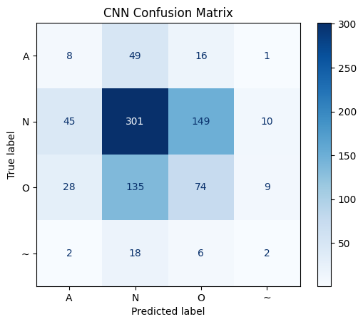

```python
cnn_cm = confusion_matrix(y_test, cnn_y_pred)
cnn_disp = ConfusionMatrixDisplay(confusion_matrix=cnn_cm, display_labels=[index_to_category[idx] for idx in range(num_classes)])
plt.figure(figsize=(6, 6))
cnn_disp.plot(cmap='Blues', values_format='d')
plt.title('CNN Confusion Matrix')
plt.show()
```

### Alternative Model

Use Keras to build another machine learning model of your choice to classify these sequences.

```python
rnn_model = Sequential([
    Input(shape=(input_length, 1)),
    SimpleRNN(16, return_sequences=False),
    Dense(16, activation='relu'),
    Dense(num_classes, activation='softmax')
])

rnn_model.compile(optimizer='adam', loss='sparse_categorical_crossentropy', metrics=['accuracy'])

rnn_history = rnn_model.fit(
    x_train, y_train,
    validation_data=(x_val, y_val),
    epochs=5,
    batch_size=32
)
```

```
214/214 ━━━━━━━━━━━━━━━━━━━━ 90s 413ms/step - accuracy: 0.5364 - loss: 1.1725 - val_accuracy: 0.5920 - val_loss: 1.0096
214/214 ━━━━━━━━━━━━━━━━━━━━ 99s 463ms/step - accuracy: 0.5989 - loss: 0.9965 - val_accuracy: 0.5920 - val_loss: 1.0049
214/214 ━━━━━━━━━━━━━━━━━━━━ 87s 405ms/step - accuracy: 0.5993 - loss: 0.9935 - val_accuracy: 0.5920 - val_loss: 0.9981
214/214 ━━━━━━━━━━━━━━━━━━━━ 82s 381ms/step - accuracy: 0.6074 - loss: 0.9781 - val_accuracy: 0.5920 - val_loss: 0.9954
214/214 ━━━━━━━━━━━━━━━━━━━━ 90s 420ms/step - accuracy: 0.5930 - loss: 0.9853 - val_accuracy: 0.5920 - val_loss: 0.9941
```

#### Alternative Model Metrics

All the metrics should be generated after predicting on the testing set.

```python
rnn_y_pred_probs = rnn_model.predict(x_test)
rnn_y_pred = np.argmax(rnn_y_pred_probs, axis=1)
```

```
27/27 ━━━━━━━━━━━━━━━━━━━━ 4s 133ms/step
```

Compute the F1 score for each class.

```python
rnn_f1_per_class = f1_score(y_test, rnn_y_pred, average=None)
for idx, score in enumerate(rnn_f1_per_class):
    print(f"F1 score for class {index_to_category[idx]}: {score}")
```

```
F1 score for class A: 0.0
F1 score for class N: 0.7437407952871871
F1 score for class O: 0.0
F1 score for class ~: 0.0
```

Compute and report the overall F1 score as the average of the computed F1 scores.

```python
rnn_overall_f1 = np.mean(rnn_f1_per_class)
print(f"Overall F1 score (average across classes): {rnn_overall_f1:.4f}")
```

```
Overall F1 score (average across classes): 0.1859
```

Report the AUC score.

```python
rnn_auc_score = roc_auc_score(y_test, rnn_y_pred_probs, average='macro', multi_class='ovr')
print(f"RNN AUC score (macro, one-vs-rest): {rnn_auc_score:.4f}")
```

```
RNN AUC score (macro, one-vs-rest): 0.5225
```

Also, construct confusion matrices.

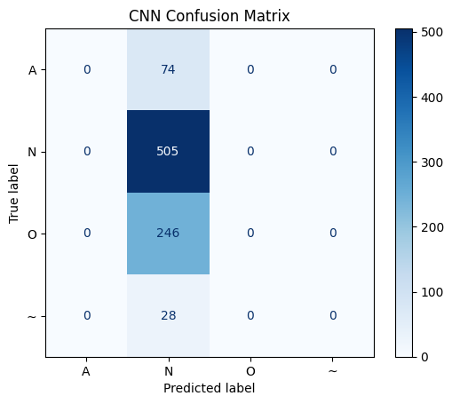

```python
rnn_cm = confusion_matrix(y_test, rnn_y_pred)
rnn_disp = ConfusionMatrixDisplay(confusion_matrix=rnn_cm, display_labels=[index_to_category[idx] for idx in range(num_classes)])
plt.figure(figsize=(6, 6))
rnn_disp.plot(cmap='Blues', values_format='d')
plt.title('CNN Confusion Matrix')
plt.show()
```

### Optimization

Optimize your models by experimenting with different choices of model architectures, hyperparameters, and/or regularization techniques.

```python
def evaluate_model(model):
    y_pred_probs = model.predict(x_test)
    y_pred = np.argmax(y_pred_probs, axis=1)
    f1_per_class = f1_score(y_test, y_pred, average=None)
    for idx, score in enumerate(f1_per_class):
        print(f"F1 score for class {index_to_category[idx]}: {score}")
    overall_f1 = np.mean(f1_per_class)
    print(f"Overall F1 score (average across classes): {overall_f1:.4f}")
    auc_score = roc_auc_score(y_test, y_pred_probs, average='macro', multi_class='ovr')
    print(f"AUC score (macro, one-vs-rest): {auc_score:.4f}")
    cm = confusion_matrix(y_test, y_pred)
    disp = ConfusionMatrixDisplay(confusion_matrix=cm, display_labels=[index_to_category[idx] for idx in range(len(index_to_category))])
    disp.plot(cmap='Blues')
    plt.title('Confusion Matrix')
    plt.show()
```

```python
def oversample_with_resample_no_noisy(x_train, y_train, class_indexes_to_omit):
    x_oversampled = []
    y_oversampled = []

    classes, counts = np.unique(y_train, return_counts=True)
    max_count = max(counts)

    for cls in classes:
        x_cls = x_train[y_train == cls]
        y_cls = y_train[y_train == cls]

        if cls in class_indexes_to_omit:
            x_up, y_up = x_cls, y_cls
        else:
            x_up, y_up = resample(x_cls, y_cls,
                                  replace=True,
                                  n_samples=max_count,
                                  random_state=the_answer)
            # Add Gaussian noise to upsampled data
            noise = np.random.normal(loc=0.0, scale=0.03, size=x_up.shape)
            x_up = x_up + noise

        x_oversampled.append(x_up)
        y_oversampled.append(y_up)

    x_bal = np.concatenate(x_oversampled)
    y_bal = np.concatenate(y_oversampled)

    indices = np.random.permutation(len(x_bal))
    return x_bal[indices], y_bal[indices]

classes_to_omit = ['~', 'N']
class_indexes_to_omit = [category_to_index[cls] for cls in classes_to_omit]
x_train_bal, y_train_bal = oversample_with_resample_no_noisy(x_train, y_train, class_indexes_to_omit)
```

```python
dnn_model_improved = Sequential([
    Input(shape=(input_length,)),
    Dense(64, activation='relu', kernel_regularizer=l2(1e-4)),
    BatchNormalization(),
    Dropout(0.3),
    Dense(32, activation='relu', kernel_regularizer=l2(1e-4)),
    BatchNormalization(),
    Dropout(0.3),
    Dense(num_classes, activation='softmax')
])
dnn_model_improved.compile(optimizer=AdamW(), loss='sparse_categorical_crossentropy', metrics=['accuracy'])
dnn_model_improved.summary()
dnn_history = dnn_model_improved.fit(
    x_train_bal, y_train_bal,
    validation_data=(x_val, y_val),
    epochs=20,
    batch_size=64,
    callbacks=[EarlyStopping(patience=3, restore_best_weights=True)]
)
```

```
Model: "sequential_22"
```

```
┏━━━━━━━━━━━━━━━━━━━━━━━━━━━━━━━━━┳━━━━━━━━━━━━━━━━━━━━━━━━┳━━━━━━━━━━━━━━━┓
┃ Layer (type)                    ┃ Output Shape           ┃       Param # ┃
┡━━━━━━━━━━━━━━━━━━━━━━━━━━━━━━━━━╇━━━━━━━━━━━━━━━━━━━━━━━━╇━━━━━━━━━━━━━━━┩
│ dense_48 (Dense)                │ (None, 64)             │       576,064 │
├─────────────────────────────────┼────────────────────────┼───────────────┤
│ batch_normalization_39          │ (None, 64)             │           256 │
│ (BatchNormalization)            │                        │               │
├─────────────────────────────────┼────────────────────────┼───────────────┤
│ dropout_26 (Dropout)            │ (None, 64)             │             0 │
├─────────────────────────────────┼────────────────────────┼───────────────┤
│ dense_49 (Dense)                │ (None, 32)             │         2,080 │
├─────────────────────────────────┼────────────────────────┼───────────────┤
│ batch_normalization_40          │ (None, 32)             │           128 │
│ (BatchNormalization)            │                        │               │
├─────────────────────────────────┼────────────────────────┼───────────────┤
│ dropout_27 (Dropout)            │ (None, 32)             │             0 │
├─────────────────────────────────┼────────────────────────┼───────────────┤
│ dense_50 (Dense)                │ (None, 4)              │           132 │
└─────────────────────────────────┴────────────────────────┴───────────────┘
```

```
 Total params: 578,660 (2.21 MB)
```

```
 Trainable params: 578,468 (2.21 MB)
```

```
 Non-trainable params: 192 (768.00 B)
```

```
193/193 ━━━━━━━━━━━━━━━━━━━━ 3s 8ms/step - accuracy: 0.3819 - loss: 1.6340 - val_accuracy: 0.4009 - val_loss: 1.3469
193/193 ━━━━━━━━━━━━━━━━━━━━ 1s 7ms/step - accuracy: 0.6568 - loss: 0.8733 - val_accuracy: 0.4748 - val_loss: 1.2541
193/193 ━━━━━━━━━━━━━━━━━━━━ 1s 7ms/step - accuracy: 0.7598 - loss: 0.6506 - val_accuracy: 0.4725 - val_loss: 1.2807
193/193 ━━━━━━━━━━━━━━━━━━━━ 1s 6ms/step - accuracy: 0.7954 - loss: 0.5654 - val_accuracy: 0.4912 - val_loss: 1.3321
193/193 ━━━━━━━━━━━━━━━━━━━━ 1s 6ms/step - accuracy: 0.8381 - loss: 0.4835 - val_accuracy: 0.4924 - val_loss: 1.4250
```

```
27/27 ━━━━━━━━━━━━━━━━━━━━ 0s 3ms/step
F1 score for class A: 0.13903743315508021
F1 score for class N: 0.5931321540062435
F1 score for class O: 0.3629489603024575
F1 score for class ~: 0.0
Overall F1 score (average across classes): 0.2738
AUC score (macro, one-vs-rest): 0.5219
```

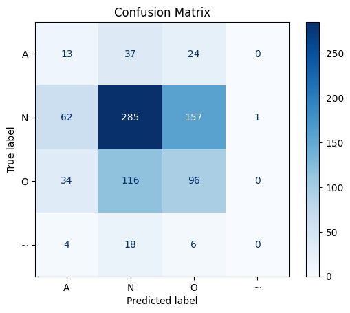

```python
evaluate_model(dnn_model_improved)
```

```python
cnn_model_improved = Sequential([
    Input(shape=(input_length, 1)),
    Conv1D(32, kernel_size=7, padding='same'),
    BatchNormalization(),
    ReLU(),
    MaxPooling1D(2),
    Conv1D(64, kernel_size=5, padding='same'),
    BatchNormalization(),
    ReLU(),
    MaxPooling1D(2),
    Flatten(),
    Dense(64, activation='relu', kernel_regularizer=l2(1e-4)),
    Dropout(0.3),
    Dense(num_classes, activation='softmax')
])
cnn_model_improved.compile(optimizer=AdamW(), loss='sparse_categorical_crossentropy', metrics=['accuracy'])
cnn_model_improved.summary()
cnn_history_improved = cnn_model_improved.fit(
    x_train_bal, y_train_bal,
    validation_data=(x_val, y_val),
    epochs=10,
    batch_size=64,
    callbacks=[EarlyStopping(patience=3, restore_best_weights=True)]
)
```

```
Model: "sequential_24"
```

```
┏━━━━━━━━━━━━━━━━━━━━━━━━━━━━━━━━━┳━━━━━━━━━━━━━━━━━━━━━━━━┳━━━━━━━━━━━━━━━┓
┃ Layer (type)                    ┃ Output Shape           ┃       Param # ┃
┡━━━━━━━━━━━━━━━━━━━━━━━━━━━━━━━━━╇━━━━━━━━━━━━━━━━━━━━━━━━╇━━━━━━━━━━━━━━━┩
│ conv1d_34 (Conv1D)              │ (None, 9000, 32)       │           256 │
├─────────────────────────────────┼────────────────────────┼───────────────┤
│ batch_normalization_43          │ (None, 9000, 32)       │           128 │
│ (BatchNormalization)            │                        │               │
├─────────────────────────────────┼────────────────────────┼───────────────┤
│ re_lu_27 (ReLU)                 │ (None, 9000, 32)       │             0 │
├─────────────────────────────────┼────────────────────────┼───────────────┤
│ max_pooling1d_32 (MaxPooling1D) │ (None, 4500, 32)       │             0 │
├─────────────────────────────────┼────────────────────────┼───────────────┤
│ conv1d_35 (Conv1D)              │ (None, 4500, 64)       │        10,304 │
├─────────────────────────────────┼────────────────────────┼───────────────┤
│ batch_normalization_44          │ (None, 4500, 64)       │           256 │
│ (BatchNormalization)            │                        │               │
├─────────────────────────────────┼────────────────────────┼───────────────┤
│ re_lu_28 (ReLU)                 │ (None, 4500, 64)       │             0 │
├─────────────────────────────────┼────────────────────────┼───────────────┤
│ max_pooling1d_33 (MaxPooling1D) │ (None, 2250, 64)       │             0 │
├─────────────────────────────────┼────────────────────────┼───────────────┤
│ flatten_10 (Flatten)            │ (None, 144000)         │             0 │
├─────────────────────────────────┼────────────────────────┼───────────────┤
│ dense_53 (Dense)                │ (None, 64)             │     9,216,064 │
├─────────────────────────────────┼────────────────────────┼───────────────┤
│ dropout_29 (Dropout)            │ (None, 64)             │             0 │
├─────────────────────────────────┼────────────────────────┼───────────────┤
│ dense_54 (Dense)                │ (None, 4)              │           260 │
└─────────────────────────────────┴────────────────────────┴───────────────┘
```

```
 Total params: 9,227,268 (35.20 MB)
```

```
 Trainable params: 9,227,076 (35.20 MB)
```

```
 Non-trainable params: 192 (768.00 B)
```

```
193/193 ━━━━━━━━━━━━━━━━━━━━ 167s 859ms/step - accuracy: 0.3242 - loss: 8.1671 - val_accuracy: 0.5920 - val_loss: 1.3686
193/193 ━━━━━━━━━━━━━━━━━━━━ 169s 877ms/step - accuracy: 0.3405 - loss: 1.3534 - val_accuracy: 0.5920 - val_loss: 1.3252
193/193 ━━━━━━━━━━━━━━━━━━━━ 162s 838ms/step - accuracy: 0.3316 - loss: 1.3110 - val_accuracy: 0.5920 - val_loss: 1.2961
193/193 ━━━━━━━━━━━━━━━━━━━━ 150s 775ms/step - accuracy: 0.3319 - loss: 1.2773 - val_accuracy: 0.5920 - val_loss: 1.2765
193/193 ━━━━━━━━━━━━━━━━━━━━ 145s 752ms/step - accuracy: 0.3301 - loss: 1.2585 - val_accuracy: 0.5920 - val_loss: 1.2628
193/193 ━━━━━━━━━━━━━━━━━━━━ 146s 756ms/step - accuracy: 0.3270 - loss: 1.2468 - val_accuracy: 0.5920 - val_loss: 1.2512
193/193 ━━━━━━━━━━━━━━━━━━━━ 145s 752ms/step - accuracy: 0.3302 - loss: 1.2277 - val_accuracy: 0.5920 - val_loss: 1.2422
193/193 ━━━━━━━━━━━━━━━━━━━━ 146s 755ms/step - accuracy: 0.3306 - loss: 1.2201 - val_accuracy: 0.5920 - val_loss: 1.2361
193/193 ━━━━━━━━━━━━━━━━━━━━ 145s 749ms/step - accuracy: 0.3352 - loss: 1.2112 - val_accuracy: 0.5920 - val_loss: 1.2312
193/193 ━━━━━━━━━━━━━━━━━━━━ 145s 754ms/step - accuracy: 0.3289 - loss: 1.2041 - val_accuracy: 0.0868 - val_loss: 1.2284
```

```
27/27 ━━━━━━━━━━━━━━━━━━━━ 2s 71ms/step
F1 score for class A: 0.15965480043149946
F1 score for class N: 0.0
F1 score for class O: 0.0
F1 score for class ~: 0.0
Overall F1 score (average across classes): 0.0399
AUC score (macro, one-vs-rest): 0.5000
```

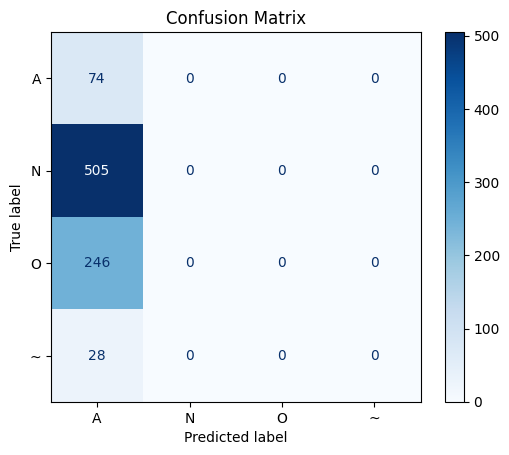

```python
evaluate_model(cnn_model_improved)
```

```python
rnn_model_improved = Sequential([
    Input(shape=(input_length, 1)),
    Conv1D(64, kernel_size=5, padding='same'),
    BatchNormalization(),
    ReLU(),
    MaxPooling1D(2),
    Conv1D(128, kernel_size=7, padding='same'),
    BatchNormalization(),
    ReLU(),
    MaxPooling1D(2),
    Bidirectional(LSTM(64, return_sequences=False)),
    Dense(64, activation='relu', kernel_regularizer=l2(1e-4)),
    Dropout(0.3),
    Dense(num_classes, activation='softmax')
])
rnn_model_improved.compile(optimizer=AdamW(), loss='sparse_categorical_crossentropy', metrics=['accuracy'])
rnn_model_improved.summary()
rnn_history_improved = rnn_model_improved.fit(
    x_train_bal, y_train_bal,
    validation_data=(x_val, y_val),
    epochs=10,
    batch_size=64,
    callbacks=[EarlyStopping(patience=3, restore_best_weights=True)]
)
```

```
Model: "sequential_18"
```

```
┏━━━━━━━━━━━━━━━━━━━━━━━━━━━━━━━━━┳━━━━━━━━━━━━━━━━━━━━━━━━┳━━━━━━━━━━━━━━━┓
┃ Layer (type)                    ┃ Output Shape           ┃       Param # ┃
┡━━━━━━━━━━━━━━━━━━━━━━━━━━━━━━━━━╇━━━━━━━━━━━━━━━━━━━━━━━━╇━━━━━━━━━━━━━━━┩
│ conv1d_29 (Conv1D)              │ (None, 9000, 64)       │           384 │
├─────────────────────────────────┼────────────────────────┼───────────────┤
│ batch_normalization_37          │ (None, 9000, 64)       │           256 │
│ (BatchNormalization)            │                        │               │
├─────────────────────────────────┼────────────────────────┼───────────────┤
│ re_lu_23 (ReLU)                 │ (None, 9000, 64)       │             0 │
├─────────────────────────────────┼────────────────────────┼───────────────┤
│ max_pooling1d_28 (MaxPooling1D) │ (None, 4500, 64)       │             0 │
├─────────────────────────────────┼────────────────────────┼───────────────┤
│ conv1d_30 (Conv1D)              │ (None, 4500, 128)      │        57,472 │
├─────────────────────────────────┼────────────────────────┼───────────────┤
│ batch_normalization_38          │ (None, 4500, 128)      │           512 │
│ (BatchNormalization)            │                        │               │
├─────────────────────────────────┼────────────────────────┼───────────────┤
│ re_lu_24 (ReLU)                 │ (None, 4500, 128)      │             0 │
├─────────────────────────────────┼────────────────────────┼───────────────┤
│ max_pooling1d_29 (MaxPooling1D) │ (None, 2250, 128)      │             0 │
├─────────────────────────────────┼────────────────────────┼───────────────┤
│ bidirectional_6 (Bidirectional) │ (None, 128)            │        98,816 │
├─────────────────────────────────┼────────────────────────┼───────────────┤
│ dense_40 (Dense)                │ (None, 64)             │         8,256 │
├─────────────────────────────────┼────────────────────────┼───────────────┤
│ dropout_25 (Dropout)            │ (None, 64)             │             0 │
├─────────────────────────────────┼────────────────────────┼───────────────┤
│ dense_41 (Dense)                │ (None, 4)              │           260 │
└─────────────────────────────────┴────────────────────────┴───────────────┘
```

```
 Total params: 165,956 (648.27 KB)
```

```
 Trainable params: 165,572 (646.77 KB)
```

```
 Non-trainable params: 384 (1.50 KB)
```

[output not shown]

[output cut: 68 more lines]

[output not shown]

```python
evaluate_model(rnn_model_improved)
```

[output not shown]